# Homework 12

## Problem #1: Bootstrap Estimation in Boston (8 pts; 1pt each)

This problem is based on Problem 9 in section 5.4 of *An Introduction to Statistical Learning*. It uses the `Boston` dataset found in the `MASS` library. Run the code below:

```r
require(MASS)
data(Boston)
str(Boston)
```

```
## 'data.frame':    506 obs. of  14 variables:
##  $ crim   : num  0.00632 0.02731 0.02729 0.03237 0.06905 ...
##  $ zn     : num  18 0 0 0 0 0 12.5 12.5 12.5 12.5 ...
##  $ indus  : num  2.31 7.07 7.07 2.18 2.18 2.18 7.87 7.87 7.87 7.87 ...
##  $ chas   : int  0 0 0 0 0 0 0 0 0 0 ...
##  $ nox    : num  0.538 0.469 0.469 0.458 0.458 0.458 0.524 0.524 0.524 0.524 ...
##  $ rm     : num  6.58 6.42 7.18 7 7.15 ...
##  $ age    : num  65.2 78.9 61.1 45.8 54.2 58.7 66.6 96.1 100 85.9 ...
##  $ dis    : num  4.09 4.97 4.97 6.06 6.06 ...
##  $ rad    : int  1 2 2 3 3 3 5 5 5 5 ...
##  $ tax    : num  296 242 242 222 222 222 311 311 311 311 ...
##  $ ptratio: num  15.3 17.8 17.8 18.7 18.7 18.7 15.2 15.2 15.2 15.2 ...
##  $ black  : num  397 397 393 395 397 ...
##  $ lstat  : num  4.98 9.14 4.03 2.94 5.33 ...
##  $ medv   : num  24 21.6 34.7 33.4 36.2 28.7 22.9 27.1 16.5 18.9 ...
```

1. Based on the data set, provide an estimate for the population mean of `medv`. Call this estimate `mu.hat`.
2. Provide an estimate of the standard error of `mu.hat`. *hint: what is $SD(\bar{X})$?
3. Now use bootstrapping to estimate the standard error of `mu.hat`. How does this compare to the estimate from b.?
4. Based on your bootstrap estimate from c., provide a 95% confidence interval for the mean of `medv`. You can either construct a Z interval or a t interval using the estimated standard error.
5. Using the quantile method compute a 95% confidence interval for the `mu` of `medv`. How does this compare to your answer in part d?
6. Now we want to estimate the standard error of the sample median of `medv`. Use bootstrapping to estimate this standard error.
7. Come up with a point estimate for the population 25th percentile of `medv`.
8. Use bootstrapping to construct a 95% confidence interval for the 25th percentile.

> SOLUTION

> ```r
> (mu.hat <- mean(Boston$medv))
> ```

> ```
> ## [1] 22.53281
> ```

> ```r
> (se.mu.hat <- sd(Boston$medv)/sqrt(nrow(Boston)))
> ```

> ```
> ## [1] 0.4088611
> ```

> ```r
> set.seed(1)
> boot.mu.hat <- 0
> for(i in 1:1000){
>   boot.medv <- sample(Boston$medv, replace=TRUE)
>   boot.mu.hat[i] <- mean(boot.medv)
> }
> (boot.se.mu.hat <- sd(boot.mu.hat))
> ```

> ```
> ## [1] 0.3974788
> ```

> The bootstrapped standard error is almost the same, but just slightly less. This is common, that bootstrapping underestimates standard error.

> ```r
> mu.hat + qnorm(c(0.025, 0.975))*boot.se.mu.hat
> ```

> ```
> ## [1] 21.75376 23.31185
> ```

> ```r
> quantile(boot.mu.hat, c(0.025, 0.975))
> ```

> ```
> ##     2.5%    97.5%
> ## 21.77213 23.30358
> ```

> ```r
> sd(replicate(1000, median(sample(Boston$medv, replace=TRUE))))
> ```

> ```
> ## [1] 0.3863414
> ```

> ```r
> quantile(Boston$medv, .25)
> ```

> ```
> ##    25%
> ## 17.025
> ```

> ```r
> quantile(replicate(1000, quantile(sample(Boston$medv, replace=TRUE), .25)), c(0.025, 0.975))
> ```

> ```
> ##     2.5%    97.5%
> ## 15.77375 17.82500
> ```

## Problem #2 Bootstrapping when Linear regression assumptions fail (10 pts)

Run the following code to produce some bivariate data:

```r
set.seed(2024)
X <- rnorm(35, 5,1)
e <- 4*rbeta(35,.25,.25)-1
Y <- 5 + 2*X + e
```

1. Come up with a point estimate for the correlation of X and Y.
2. Use bootstrapping to create a 95% confidence interval for $\rho$.
3. Fit a linear model predicting Y from X. Comment on the diagnostic plots. Are the assumptions of linear regression met?
4. Spoiler alert - the errors are not normally distributed. Why would it be problematic to use the coefficient confidence intervals estimated by R using `confint` in this case?
5. Use bootstrapping to construct a 95% confidence interval for the slope coefficient.

> SOLUTION
> 1. A point estimate for the correlation is the sample correlation, 0.8087628.

> ```r
> boot.cor <- 0
> for(i in 1:1000){
>   bootRows <- sample(1:length(X), replace=TRUE)
>   boot.cor[i] <- cor(X[bootRows], Y[bootRows])
> }
> quantile(boot.cor, c(0.025,0.975))
> ```

> ```
> ##      2.5%     97.5%
> ## 0.7141022 0.8850964
> ```

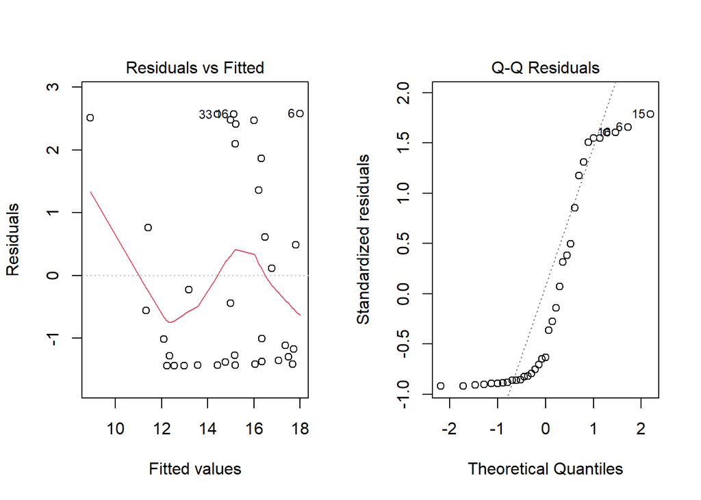

> ```r
> linear.fit <- lm(Y~X)
> par(mfrow=c(1,2))
> plot(linear.fit, which=1:2)
> ```

> ```r
> par(mfrow=c(1,1))
> ```

> There is roughly constant variance but the residuals are not normally distributed.
> 4. If we used `confint` to calculate confidence intervals for $\beta$ s, the formula will rely on the normality assumption to estimate $\sigma^2$. The residuals are bimodal and a normal distribution is unimodal with the concentration in the middle. A normality assumption may give an underestimate of the variance and thus a confidnece interval that is too narrow.

> ```r
> boot.b1 <- 0
> for(i in 1:1000){
>   bootRows <- sample(1:length(X), replace=TRUE)
>   boot.b1[i] <- coef(lm(Y[bootRows]~X[bootRows]))[2]
> }
> quantile(boot.b1, c(0.025, 0.975))
> ```

> ```
> ##     2.5%    97.5%
> ## 1.533206 2.573903
> ```

> Compare this to

> ```r
> confint(linear.fit)["X",]
> ```

> ```
> ##    2.5 %   97.5 %
> ## 1.476903 2.501550
> ```

## Problem #3 Bootstrapping A Tricky Estimator (6 pts)

If you have $X_1 \sim \text{Binomial}(n,p)$ we know that $\hat{P}=\frac{X_1}{n}$ is a good point estimate of $p$. What if, however we don’t know $n$? The following 20 values were independently sampled from a binomial distribution with unknown parameters $n$ and $p$.

```r
binomialData <- c(25,23,23,23,30,20,27,23,20,15,24,20,19,27,28,20,28,27,17,25)
```

Our task is to come up with a 95% confidence interval for $p$ without knowing $n$. We can do it!

1. Using the method of moments we can use $1-S^2/\bar{X}$ as a point estimate of $p$. Justify this estimator.
2. Use this estimator to come up with a point estimate of $p$
3. Use bootstrapping to produce a 95% confidence interval for $p$.
4. *Extra Practice:* It follows that $\frac{\bar{X}^2}{\bar{X}-S^2}$ is a good estimate of $n$. Produce a point estimate of $n$
5. *Extra Practice:* Use bootstrapping to come up with a 95% confidence interval for $n$.

**Just so you know, These 20 points were generated from Binomial(80, .3)**

> SOLUTION
> 1. Since $E(\bar{X})=np$ and $E(S^2)=np(1-p)$, The method of moments suggest that $\dfrac{S^2}{\bar{X}}\approx \frac{np(1-p)}{np}=1-p$. Hence $p \approx 1-\dfrac{S^2}{\bar{X}}$.

> ```r
> 1-var(binomialData)/mean(binomialData)
> ```

> ```
> ## [1] 0.3030853
> ```

> ```r
> boot.p.hat <- 0
> for(i in 1:1000){
>   boot.data <- sample(binomialData, replace=TRUE)
>   boot.p.hat[i] <- 1-var(boot.data)/mean(boot.data)
> }
> quantile(boot.p.hat, c(0.025, 0.975))
> ```

> ```
> ##        2.5%       97.5%
> ## -0.02700651  0.65565896
> ```

> ```r
> mean(binomialData)^2 / (mean(binomialData)-var(binomialData))
> ```

> ```
> ## [1] 76.54611
> ```

> ```r
> boot.n.hat <- 0
> for(i in 1:1000){
>   boot.data <- sample(binomialData, replace=TRUE)
>   boot.n.hat[i] <- mean(boot.data)^2 / (mean(boot.data)-var(boot.data))
> }
> quantile(boot.n.hat, c(0.025, 0.975))
> ```

> ```
> ##      2.5%     97.5%
> ## -145.2349  582.5217
> ```

> Obviously this interval is far too wide. The interval gets extremely wide due to the denominator. And there’s no reason for the interval to include negative values for $n$. This could be a case where the bootstrap method is not ideal, though it’s not obvious what the sampling distribution of $\hat{n}$ and $\hat{p}$ truly are.

## Problem #4 When Bootstrapping Fails (6 pts; 2pts each)

An estimate problem we’ve seen before is estimating the maximum of a population. Suppose we have a random variable $X \sim \text{Uniform}(0, \theta)$ for some unknown maximum $\theta$.

A 95% confidence interval for $\theta$ coming from statistical theory would be $(max, max\cdot(.05)^{-1/n})$

For example, suppose we have the following 15 values drawn from a uniform distribution with a minimum of 0 and an unknown maximum:

```r
uniformData <- c(24.57,  7.94, 32.81, 24.89, 24.53,
                 23.36,  4.15,  0.64,  0.89,  4.02,
                  2.67,  3.93,  1.44, 16.11, 15.86)
```

1. Use the formula to come up with a 95% confidence interval for the maximum.
2. An unbiased point estimate of the population maximum would be $\hat{\theta}=\frac{n+1}{n}max$. Use this formula to come up with a point estimate for the population maximum.
3. Now we’ll put bootstrapping to the test. Come up with a 95% bootstrap interval for the population max using the above point estimate on each bootstrapped sample and compute the 95% confidence interval based on the quantile method. How does this compare?

**Spoiler Alert: The population maximum used when generating the data was actually 33**

4. Extra Practice: Estimate the coverage rate of the two methods used above on 20 data points sampled from $\text{Uniform}(0, 33)$.

> SOLUTION

> ```r
> c(max(uniformData), max(uniformData)*.05^(-1/length(uniformData)))
> ```

> ```
> ## [1] 32.81000 40.06282
> ```

> ```r
> (1+length(uniformData))/length(uniformData)*max(uniformData)
> ```

> ```
> ## [1] 34.99733
> ```

> ```r
> nB <- 1000
> boot.Max <- 0
> for(i in 1:nB){
>   bootData <- sample(uniformData, replace=TRUE)
>   boot.Max[i] <- (1+length(bootData))/length(bootData)*max(bootData)
> }
> quantile(boot.Max, c(0.025, 0.975))
> ```

> ```
> ##     2.5%    97.5%
> ## 26.16533 34.99733
> ```

> ```r
> NMC <- 1000
> nB <- 1000
> coverage.formula <- 0
> coverage.bootstrap <- 0
> for(i in 1:NMC){
>   uniformData <- runif(20, 0, 33)
>
>   #Construct the formulaic confidence interval
>   CI <- c(max(uniformData), max(uniformData)*.05^(-1/length(uniformData)))
>
>   #in coverage.formula[i] store whether or not it contains 33
>   coverage.formula[i] <- CI[1]<=33 & CI[2]>=33
>
>   #Resample in order to create a 95% bootstrap interval for theta
>   boot.Max <- 0
>   for(k in 1:nB){
>     bootData <- sample(uniformData, replace=TRUE)
>     boot.Max[k] <- (1+length(bootData))/length(bootData)*max(bootData)
>   }
>   CI <- quantile(boot.Max, c(0.025, 0.975))
>
>   #in coverage.bootstrap[i] store whether or not it contains 33
>   coverage.bootstrap[i] <-  CI[1]<=33 & CI[2]>=33
> }
> mean(coverage.formula)
> ```

> ```
> ## [1] 0.934
> ```

> ```r
> mean(coverage.bootstrap)
> ```

> ```
> ## [1] 0.61
> ```

> The formulaic confidence interval has a coverage of rate of 0.934 whereas the bootrap confidence interval has an awful coverage rate of 0.61.